# GROUP3_task4

## IMPORT AND SETUP

```python
import numpy as np
import matplotlib.pyplot as plt
from scipy.stats import norm
from matplotlib.lines import Line2D
from ipywidgets import interact, FloatSlider
import pandas as pd
from IPython.display import display
```

```python
# -----------------------------------------------------
# GLOBAL MODEL PARAMETER
# -----------------------------------------------------

# 1. DEFINE MODEL PARAMETER

S = 100         # Current stock price
K = 100         # Strike price
r = 0.05        # Risk-free interest rate
sigma = 0.20    # Volatility
tau = 1.0       # Time to maturity
```

## 4.0 GENERAL INFORMATION AND ASSUMPTIONS

4.0.1 GENERAL ASSUMPTIONS:

- European options
- Underlying: non-dividend-paying stock
- Assumptions of the Black-Scholes model:
  - constant risk-free interest rate
  - constant volatility
  - no transaction costs or taxes

4.0.2 FIGURE: STRADDLE

- Vanilla components: straddle consists of
- a call and put option
- written on the same underlying asset
- with the same Strike Price K
- and same maturity T

  Types:

-> This analysis focuses on the long straddle, because it is the standard version of the strategy and is well suited for understanding the main economic idea of benefiting from large price movements

## 4.1 A GENERAL DESCRIPTION OF AN OPTION'S PAYOFF STRUCTURE *(composition, payoff function, possibly conditions for payoff, etc.)*

4.1.1 COMPOSITION OF PAYOFF STRUCTURE

The payoff of a straddle is a combination of the payoff of a call option and the payoff of a put option. The initial option premiums are not included in the payoff itself. They are relevant for the profit and risk profile, which will be considered later in the analysis.

Payoff functions of the call and put option:

$$ \text{Payoff}_{Call}= \max(S_T - K,0) $$

$$ \text{Payoff}_{Put} = \max(K - S_T,0) $$

Payoff-structure of the long straddle:

$$ \text{Payoff}_{straddle} = \max(S_T-K,0) + \max(K-S_T,0) = |S_T-K| $$

4.1.2 PAYOFF CONDITIONS AT MATURITY

$$ \text{Payoff}_{Straddle} = \begin{cases} K - S_T, & S_T < K, \\ 0, & S_T = K, \\ S_T - K, & S_T > K. \end{cases} $$

**Case 1: $S_T < K$**

The put option is in-the-money and the call option expires worthless. The payoff of the straddle is therefore generated by the put option:

$$ \text{Payoff}_{Straddle} = K - S_T $$

**Case 2: $S_T = K$**

Both options are at-the-money and have no intrinsic value at maturity. Therefore, the total payoff is:

$$ \text{Payoff}_{Straddle} = 0 $$

**Case 3: $S_T > K$**

The call option is in-the-money and the put option expires worthless. The payoff of the straddle is therefore generated by the call option:

$$ \text{Payoff}_{Straddle} = S_T - K $$

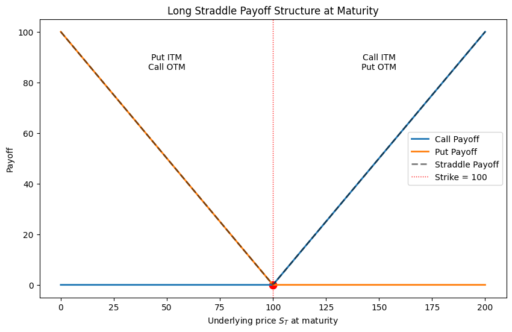

```
The long straddle has a V-shaped payoff structure.

If the underlying price moves away from the strike price in either direction, the payoff increases.
At S_T = K, the straddle payoff is minimized: In this case, both options are at-the-money and have zero intrinsic value at maturity.
For S_T > K, the call option becomes in-the-money and drives the payoff.
For S_T < K, the put option becomes in-the-money and drives the payoff.

This illustrates that the strategy benefits from large price movements in either direction.
```

```python
# -----------------------------------------------------------
# 4.1.3 VISUALIZATION OF THE LONG STRADDLE PAYOFF STRUCTURE
# -----------------------------------------------------------

# 1. STOCK PRICES AT MATURITY
S_t = np.linspace(0, 200, 500)

# 2. PAYOFF CALL, PUT, STRADDLE AT MATURITY
call_payoff = np.maximum(S_t - K, 0)
put_payoff = np.maximum(K - S_t, 0)
straddle_payoff = call_payoff + put_payoff

# Calculate maximum straddle payoff for annotation
max_straddle_payoff = np.max(straddle_payoff)

# 3. PLOT PAYOFF
# Define figure size
plt.figure(figsize=(10, 6))

# Generate payoff lines for call, put, and straddle
plt.plot(S_t, call_payoff, label="Call Payoff", linewidth=2)
plt.plot(S_t, put_payoff, label="Put Payoff", linewidth=2)
plt.plot(
    S_t,
    straddle_payoff,
    label="Straddle Payoff",
    linewidth=2,
    linestyle="--",
    color="black",
    alpha=0.5
)

# Add vertical line at strike price
plt.axvline(
    K,
    color="red",
    linestyle=":",
    linewidth=1,
    label=f"Strike = {K}",
)

# Add red dot at strike
plt.scatter(K, 0, color="red", s=80)

# Add moneyness
# Put side
plt.text(
    K / 2,  # Poition text
    max_straddle_payoff * 0.85,  # Position text
    "Put ITM\nCall OTM",
    ha="center",  # Alignment
    fontsize=10,
)

# Call side
plt.text(
    1.5 * K,
    max_straddle_payoff * 0.85,
    "Call ITM\nPut OTM",
    ha="center",
    fontsize=10,
)

# Add title, label ,legend
plt.title("Long Straddle Payoff Structure at Maturity")
plt.xlabel("Underlying price $S_T$ at maturity")
plt.ylabel("Payoff")

# Add legend
plt.legend()

# Show plot
plt.show()

# 4. INTERPRETATION

print("The long straddle has a V-shaped payoff structure.")
print("")
print(
    "If the underlying price moves away from the strike price in "
    "either direction, the payoff increases."
)
print(
    "At S_T = K, the straddle payoff is minimized: In this case,"
    " both options are at-the-money"
    " and have zero intrinsic value at maturity."
)
print(
    "For S_T > K, the call option becomes in-the-money"
    " and drives the payoff."
)
print(
    "For S_T < K, the put option becomes in-the-money"
    " and drives the payoff."
)
print("")
print(
    "This illustrates that the strategy benefits"
    " from large price movements in either direction."
)
```

## 4.2 DEFINE FUNCTION OF BLACK-SCHOLES-MODEL *A function bsOption() that returns either the values of European call or put options for given input parameters, in a vectorized manner*

4.2.1 GENERAL PARAMETER DEFINITION:

- S : Current stock price of underlying asset
- K : Strike Price
- $\tau$ = T - t : Remaining time to maturity
- r : Risk-free rate
- sigma : Volatility

4.2.2 DEFINITION OF THE BLACK-SCHOLES-MODEL FORMULA

$$ d_1 = \frac{ \ln\left(\frac{S}{K}\right) + \left(r + \frac{1}{2}\sigma^2\right)\tau }{ \sigma \sqrt{\tau} } $$

$$ d_2 = d_1 - \sigma \sqrt{\tau} $$

Call Price: $$ \text{Call}_{BSM} = S \Phi(d1) - Ke^{-r\tau}\Phi(d2) $$ Put Price: $$ \text{Put}_{BSM}= Ke^{-r\tau}\Phi(-d2) - S\Phi(-d1) $$

The value of a long straddle can be obtained as the sum of the corresponding European call and put option prices:

$$ V_{\text{Straddle}} = C_{\text{BSM}} + P_{\text{BSM}} $$

```python
# ---------------------------------------------------------------------------
# 4.2.3 BLACK-SCHOLES AUXILIARY FUNCTION
# ---------------------------------------------------------------------------


# DEFINE FUNCTION FOR d1, d2
def d1_d2(S, K, r, sigma, tau):
    # Condition for valid input parameters
    if sigma <= 0 or tau <= 0:
        raise ValueError("Volatility and time to maturity must be positive.")

    # Calculate d1 and d2
    d1 = (
        np.log(S / K) + (r + 0.5 * sigma**2) * tau
    ) / (sigma * np.sqrt(tau))
    d2 = d1 - sigma * np.sqrt(tau)

    return d1, d2
```

```python
# ----------------------------------------------------------------------------
# 4.2.4 BLACK-SCHOLES-MODEL OPTION PRICING FUNCTION
# ----------------------------------------------------------------------------


# DEFINE BLACK-SCHOLES FUNCTION
def bsOption(S, K, r, sigma, tau, option_type):

    # Use d1, d2 from auxiliary function
    d1, d2 = d1_d2(S, K, r, sigma, tau)

    # Calculate price for european call
    if option_type == "Call":
        return S * norm.cdf(d1) - K * np.exp(-r * tau) * norm.cdf(d2)

    # Calculate price for European Put
    elif option_type == "Put":
        return K * np.exp(-r * tau) * norm.cdf(-d2) - S * norm.cdf(-d1)

    # Raise error if option type is neither call or put
    else:
        raise ValueError("Option type must be either Call or Put")
```

```python
# ----------------------------------------------------------------------------
# 4.2.5 APPLICATION
# ----------------------------------------------------------------------------


# 1. SINGLE STOCK PRICE S = 100

# Print spot price from defined parameters
print(f"For S = {S:.0f} :")
print("")

# Calculate BSM-price for call
call_price = bsOption(S, K, r, sigma, tau, "Call")
print("Call Price:", round(call_price, 4))

# Calculate BS-price for put
put_price = bsOption(S, K, r, sigma, tau, "Put")
print("Put Price:", round(put_price, 4))

# Calculate BS-price for straddle
straddle_price = call_price + put_price
print("Straddle Price:", round(straddle_price, 4))
print("")


# 2. MULTIPLE STOCK PRICES

# Array with multiple stock prices
S_values = np.array([80, 90, 100, 110, 120])

# Print spot values
print("For S =", S_values, ":")
print("")

# Calculate BSM-price for call, put, straddle
call_prices = bsOption(S_values, K, r, sigma, tau, "Call")
put_prices = bsOption(S_values, K, r, sigma, tau, "Put")
straddle_prices = call_prices + put_prices

# Results as table
results = pd.DataFrame({
    "Underlying Price S": S_values,
    "Call Price": call_prices,
    "Put Price": put_prices,
    "Straddle Price": straddle_prices
})

# Show results as table
display(results.round(4))
```

```
For S = 100 :

Call Price: 10.4506
Put Price: 5.5735
Straddle Price: 16.0241

For S = [ 80  90 100 110 120] :
```

|  | Underlying Price S | Call Price | Put Price | Straddle Price |
| --- | --- | --- | --- | --- |
| 0 | 80 | 1.8594 | 16.9824 | 18.8418 |
| 1 | 90 | 5.0912 | 10.2142 | 15.3054 |
| 2 | 100 | 10.4506 | 5.5735 | 16.0241 |
| 3 | 110 | 17.6630 | 2.7859 | 20.4488 |
| 4 | 120 | 26.1690 | 1.2920 | 27.4610 |

## 4.3 + 4.4 FUNCTIONS TO CALCULATE THE RESPEKTIVE GREEKS OF THE OPTION AND FITTING VISUAL REPRESENTATION AND ECONOMIC INTERPRETATION

General calculation structure for Straddle:

$$ {Greek}_{Straddle} = {Greek}_{Call} + {Greek}_{Put} $$

## 4.3.1 DELTA

4.3.1.1 CALCULATION

*Measures much the option value changes when the underlying asset price changes by one unit*

$$ \Delta = \frac{\partial V}{\partial S} $$

$$ \Delta_{Call}= \Phi(d_1) $$

$$ \Delta_{Put}= \Phi(d_1)-1 $$

```python
# ----------------------------------------------------------------
# 4.3.1.2 FUNCTION DELTA
# ---------------------------------------------------------------


# DEFINE FUNCTION FOR DELTA
# Delta of call option = N(d1)
def delta_call(S, K, r, sigma, tau):
    # Values from function d1, d2
    d1, d2 = d1_d2(S, K, r, sigma, tau)
    return norm.cdf(d1)


# Delta of put = N(d1)-1
def delta_put(S, K, r, sigma, tau):
    # Values from function d1, d2
    d1, d2 = d1_d2(S, K, r, sigma, tau)
    return norm.cdf(d1) - 1


# Delta straddle: delta_straddle = delta call + delta_put
def delta_straddle(S, K, r, sigma, tau):
    return delta_call(S, K, r, sigma, tau) + delta_put(S, K, r, sigma, tau)
```

4.3.1.3 VISUALIZATION - EXPECTATIONS

| Situation | Call | Put | Straddle |
| --- | --- | --- | --- |
| S >> K | approx. 1 | approx. 0 | approx. 1 |
| S = K | approx. 0.5 | approx. -0.5 | approx. 0 |
| S << K | approx. 0 | approx. -1 | approx. -1 |

*However, due to the positive risk-free rate and time to maturity, the results might slightly deviate*

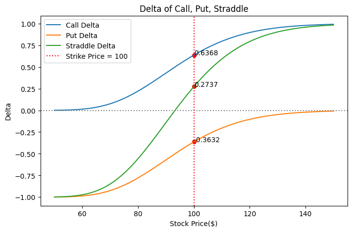

```
AT STRIKE PRICE K = 100:

Call Delta = 0.6368
If the stock price increases by $1, the value of the call option increases approximately by: $0.6368.

Put Delta = -0.3632
If the stock price increases by $1, the value of the put option decreases approximately by: $0.3632.

Straddle Delta = 0.2737
If the stock price increases by $1, the value of the straddle increases approximately by: $0.2737.

THE RESULTS ARE CONSISTENT WITH THE EXPECTATIONS:
Small deviations occur due to specific parameters used in the Black-Scholes model.
For low stock prices, the put option dominates and the straddle delta approaches -1.
For high stock prices, the call option dominates and the straddle delta approaches +1.
Around the strike price, the positive delta of the call and the negative delta of the put partially offset each other.
Therefore, the straddle delta is relatively close to zero.
```

```python
# --------------------------------------------------------------
#  4.3.1.3 VISUALIZATION & INTERPRETATION
# --------------------------------------------------------------

# 1. VISUALIZING
# Generate a range of stock prices
S_values = np.linspace(50, 150, 200)

# Delta of call, put, straddle from defined function
call_delta = delta_call(S_values, K, r, sigma, tau)
put_delta = delta_put(S_values, K, r, sigma, tau)
straddle_delta = delta_straddle(S_values, K, r, sigma, tau)

# Create figure
# Set figure size
plt.figure(figsize=(8, 5))

# Plot delta for call, put, straddle
plt.plot(S_values, call_delta, label="Call Delta")
plt.plot(S_values, put_delta, label="Put Delta")
plt.plot(S_values, straddle_delta, label="Straddle Delta")

# Add label and title
plt.xlabel("Stock Price($)")
plt.ylabel("Delta")
plt.title("Delta of Call, Put, Straddle")

# Add horizontal line at delta = 0
plt.axhline(0, color="grey", linestyle=":")

# Add vertical line at strike price
plt.axvline(x=K,
            color="red",
            linestyle=":",
            label=f"Strike Price = {K}"
            )

# Calculate delta values at strike price
call_k = delta_call(K, K, r, sigma, tau)
put_k = delta_put(K, K, r, sigma, tau)
straddle_k = delta_straddle(K, K, r, sigma, tau)

# Mark delta values at strike price
plt.scatter(K, call_k, color="red", s=30)
plt.scatter(K, put_k, color="red", s=30)
plt.scatter(K, straddle_k, color="red", s=30)

# Annotate delta values at strike price
plt.annotate(f"{call_k:.4f}", (K, call_k))
plt.annotate(f"{put_k:.4f}", (K, put_k))
plt.annotate(f"{straddle_k:.4f}", (K, straddle_k))

# Add legend
plt.legend()

# Show plot
plt.show()


# 2.INTERPRETATION

print(f"AT STRIKE PRICE K = {K}:")
print("")

print(f"Call Delta = {call_k:.4f}")
print(
    "If the stock price increases by $1, "
    f"the value of the call option increases approximately by: ${call_k:.4f}."
)
print("")

print(f"Put Delta = {put_k:.4f}")
print(
    "If the stock price increases by $1, the value of "
    f"the put option decreases approximately by: ${abs(put_k):.4f}."
)
print("")

print(f"Straddle Delta = {straddle_k:.4f}")
print(
    "If the stock price increases by $1, "
    f"the value of the straddle increases approximately by: ${straddle_k:.4f}."
)
print("")

print("THE RESULTS ARE CONSISTENT WITH THE EXPECTATIONS:")
print(
    "Small deviations occur due to specific parameters "
    "used in the Black-Scholes model."
)
print(
    "For low stock prices, the put option dominates and the straddle "
    "delta approaches -1."
)
print(
    "For high stock prices, the call option dominates and the straddle "
    "delta approaches +1."
)
print(
    "Around the strike price, the positive delta of the call and the "
    "negative delta of the put partially offset each other."
)
print("Therefore, the straddle delta is relatively close to zero.")
```

## 4.3.2 VEGA

4.3.2.1 CALCULATION

*Measures the sensitivity of the option value with respect to the change in volatility*

$$ \text{Vega} = \frac{\partial V} {\partial \sigma} $$

$$ \text{Vega}_{Straddle} = 2S \cdot \varphi(d_1) \cdot \sqrt{ \tau} $$

```python
# --------------------------------------------------------
# 4.3.2.2 FUNCTION VEGA
# --------------------------------------------------------


# DEFINE FUNCTION FOR VEGA

# Vega call
def vega_call(S, K, r, sigma, tau):
    # Values from function d1, d2
    d1, d2 = d1_d2(S, K, r, sigma, tau)
    return S * norm.pdf(d1) * np.sqrt(tau)


# Vega put
def vega_put(S, K, r, sigma, tau):
    # Values from function d1, d2
    d1, d2 = d1_d2(S, K, r, sigma, tau)
    return S * norm.pdf(d1) * np.sqrt(tau)


# Vega straddle: vega_straddle = vega_call + vega_put
def vega_straddle(S, K, r, sigma, tau):
    return vega_call(S, K, r, sigma, tau) + vega_put(S, K, r, sigma, tau)
```

4.3.2.3 VISUALIZATION - EXPECTATIONS

| Situation | Call | Put | Straddle |
| --- | --- | --- | --- |
| S >> K | ~0 | ~0 | ~0 |
| S = K | max | max | highest |
| S << K | ~0 | ~0 | ~0 |

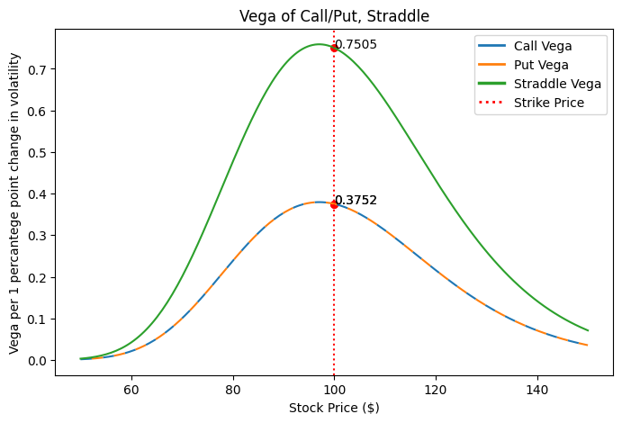

```
Vega measures the sensitivity of the option value with respect to changes in volatility.
Since vega is divided by 100, the values show the change in option price for a 1 percentage point increase in volatility.
Call vega equals put vega.

If volatility increases by 1 percentage point, the value of the call and put option each increases by approximately $0.3752.
If volatility increases by 1 percentage point, the value of the straddle increases by approximately $0.7505.

THE RESULTS ARE CONSISTENT WITH THE EXPECTATIONS:
Small deviations occur due to specific parameters used in the Black-Scholes model.
Vega reaches its maximum around the strike price, where the option is at-the-money.
At this point, changes in volatility have the most impact on the future payoff.
The straddle has the highest vega because it combines the vega of the call and the vega of the put.
```

```python
# ---------------------------------------------------------------------
# 4.3.2.3 VISUALIZATION & INTERPRETATION
# ---------------------------------------------------------------------

# 1. GENERATE RANGE OF STOCK PRICES
S_values = np.linspace(50, 150, 200)

# 2. VEGA IN PERCENTAGE POINTS FOR INTERPRETATION

call_vega_pct = vega_call(S_values, K, r, sigma, tau) / 100
put_vega_pct = vega_put(S_values, K, r, sigma, tau) / 100
straddle_vega_pct = vega_straddle(S_values, K, r, sigma, tau) / 100

# 3. VISUALIZE

# Set figure size
plt.figure(figsize=(8, 5))

# Plot vega for call, put and straddle
plt.plot(S_values,
         call_vega_pct,
         label="Call Vega",
         linestyle=(0, (6, 6))
         )
plt.plot(S_values,
         put_vega_pct,
         label="Put Vega",
         linestyle=(6, (6, 6))
         )
plt.plot(S_values, straddle_vega_pct, label="Straddle Vega")

# Add label, title, legend
plt.xlabel("Stock Price ($)")
plt.ylabel("Vega per 1 percantege point change in volatility")
plt.title("Vega of Call/Put, Straddle")

# Add vertical line at strike price
plt.axvline(x=K, color="red", linestyle=":", label="Strike Price")

# Calculate vega at strike price for call, put, straddle
call_k_pct = vega_call(K, K, r, sigma, tau) / 100
put_k_pct = vega_put(K, K, r, sigma, tau) / 100
straddle_k_pct = vega_straddle(K, K, r, sigma, tau) / 100

# Mark values of vega at strike price
plt.scatter(K, call_k_pct, color="red", s=30)
plt.scatter(K, put_k_pct, color="red", s=30)
plt.scatter(K, straddle_k_pct, color="red", s=30)

# Annotate vega at strike price
plt.annotate(f"{call_k_pct:.4f}", (K, call_k_pct))
plt.annotate(f"{put_k_pct:.4f}", (K, put_k_pct))
plt.annotate(f"{straddle_k_pct:.4f}", (K, straddle_k_pct))

# 4. ADD LEGEND
# Generate manual legend for dashed lines
legend_elements = [
    Line2D([0], [0], color="tab:blue", lw=2, linestyle="-", label="Call Vega"),
    Line2D(
        [0],  # x-value for legend
        [0],  # y-value for legend
        color="tab:orange",  # Color in legend
        linewidth=2,
        linestyle="-",
        label="Put Vega"),
    Line2D(
        [0],
        [0],
        color="tab:green",
        linewidth=2.5,
        linestyle="-",
        label="Straddle Vega"),
    Line2D(
        [0],
        [0],
        color="red",
        linewidth=2,
        linestyle=":",
        label="Strike Price")
]

# Plot manual legend
plt.legend(handles=legend_elements)

# Show plot
plt.show()

# 5. INTERPRETATION

print(
    "Vega measures the sensitivity of the option value with respect to "
    "changes in volatility."
)
print(
    "Since vega is divided by 100, the values show the change in option "
    "price for a 1 percentage point increase in volatility."
)
print("Call vega equals put vega.")
print("")

print(
    "If volatility increases by 1 percentage point, "
    "the value of the call and put option "
    f"each increases by approximately ${call_k_pct:.4f}."
)
print(
    "If volatility increases by 1 percentage point, the value of the "
    f"straddle increases by approximately ${straddle_k_pct:.4f}."
)
print("")

print("THE RESULTS ARE CONSISTENT WITH THE EXPECTATIONS:")
print(
    "Small deviations occur due to specific parameters "
    "used in the Black-Scholes model."
)
print(
    "Vega reaches its maximum around the strike price, where the option "
    "is at-the-money."
)
print(
    "At this point, changes in volatility have the most impact on "
    "the future payoff."
)
print(
    "The straddle has the highest vega because it combines the vega of "
    "the call and the vega of the put."
)
```

## 4.3.3 THETA

4.3.3.1 CALCULATION

*Measures how the option value changes as time passes*

Theta shows how the option value changes as time passes.

$\tau$ denotes the remaining time to maturity:

$$ \tau = T - t $$

$\tau$ becomes smaller if time passes. Therefore, Theta is usually negative for long options, because they lose time value over time.

$$ \Theta = \frac{\partial V}{\partial t} = -\frac{\partial V}{\partial \tau} $$

$$ \Theta_{Call}= -\frac{S \cdot \phi(d_1)\cdot \sigma}{2\sqrt{\tau}}-rKe^{-r\tau}\ N(d_2) $$

$$ \Theta_{Put}= -\frac{S \cdot \phi(d_1)\cdot \sigma}{2\sqrt{\tau}}+rKe^{-r\tau} N(-d_2) $$

$$ \Theta_{Straddle}= -\frac{S \cdot \phi(d_1)\cdot \sigma}{\sqrt{\tau}}+rKe^{-r\tau}\Big(N(-d_2)-N(d_2)\Big) $$

```python
# --------------------------------------------------------
# 4.3.3.2 FUNCTION THETA
# --------------------------------------------------------


# DEFINE FUNCTIONS
# Theta call
def theta_call(S, K, r, sigma, tau):
    # Values from function d1, d2
    d1, d2 = d1_d2(S, K, r, sigma, tau)
    return (
        - (S * norm.pdf(d1) * sigma) / (2 * np.sqrt(tau))
        - r * K * np.exp(-r * tau) * norm.cdf(d2)
    )


# Theta put
def theta_put(S, K, r, sigma, tau):
    # Vaues from function d1, d2
    d1, d2 = d1_d2(S, K, r, sigma, tau)
    return (
        - (S * norm.pdf(d1) * sigma) / (2 * np.sqrt(tau))
        + r * K * np.exp(-r * tau) * norm.cdf(-d2)
    )


# Theta straddle = theta call + theta put
def theta_straddle(S, K, r, sigma, tau):
    return theta_call(S, K, r, sigma, tau) + theta_put(S, K, r, sigma, tau)
```

4.3.3.3 VISUALIZATION - EXPECTATIONS

| Situation | Call | Put | Straddle |
| --- | --- | --- | --- |
| S >> K | negative | ~0 | negative |
| S = K | most negative | most negative | most negative |
| S << K | ~0 | positive | positive |

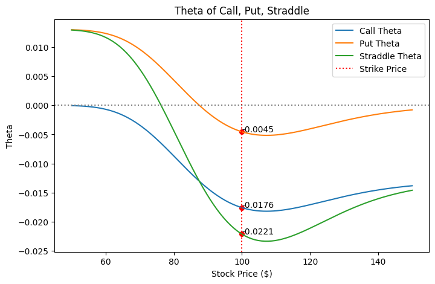

```
Theta measures the loss in option value caused by the passage of time.
This plot uses daily theta values, since annual theta is divided by 365.

At the strike price K = 100:

Call Theta = -0.0176
The value of the call option decreases approximately by $0.0176 per day due to time decay.

Put Theta = -0.0045
The value of the put option decreases approximately $0.0045 per day due to time decay.

Straddle Theta = -0.0221
The value of thelong straddle decreases approximately $0.0221 per day due to time decay.

THE RESULTS ARE CONSISTENT WITH THE EXPECTATIONS:
Small deviations occur due to specific parameters used in the Black-Scholes model.
Theta is most negative around the strike price, where the options are at-the-money.
At this point, both the call and the put contain a high amount of time value, which leads to the strongest time decay.
Therefore, the long straddle has the strongest negative theta around the strike price.
```

```python
# ----------------------------------------------------------------
# 4.3.3.4 VISUALIZATION & INTERPRETATION
# ----------------------------------------------------------------

# 1. GENERATE RANGE OF STOCK PRICES
S_values = np.linspace(50, 150, 200)

# 2. CALCULATE THETA FOR EACH STOCK PRICE
call_theta_day = theta_call(S_values, K, r, sigma, tau) / 365
put_theta_day = theta_put(S_values, K, r, sigma, tau) / 365
straddle_theta_day = theta_straddle(S_values, K, r, sigma, tau) / 365

# 3. CREATE PLOT

# Set figure size
plt.figure(figsize=(8, 5))

# Plot theta for call, put, straddle
plt.plot(S_values, call_theta_day, label="Call Theta")
plt.plot(S_values, put_theta_day, label="Put Theta")
plt.plot(S_values, straddle_theta_day, label="Straddle Theta")

# Add label, title
plt.xlabel("Stock Price ($)")
plt.ylabel("Theta")
plt.title("Theta of Call, Put, Straddle")

# Add vertical line at strike price
plt.axvline(x=K, color="red", linestyle=":", label="Strike Price")
# Add horizontal line at theta = 0
plt.axhline(0, color="grey", linestyle=":")

# Calculate theta at strike
call_theta_k_day = theta_call(K, K, r, sigma, tau) / 365
put_theta_k_day = theta_put(K, K, r, sigma, tau) / 365
straddle_theta_k_day = theta_straddle(K, K, r, sigma, tau) / 365

# Mark theta at strike
plt.scatter(K, call_theta_k_day, color="red", s=30)
plt.scatter(K, put_theta_k_day, color="red", s=30)
plt.scatter(K, straddle_theta_k_day, color="red", s=30)

# Annotate theta at strike
plt.annotate(f"{call_theta_k_day:.4f}", (K, call_theta_k_day))
plt.annotate(f"{put_theta_k_day:.4f}", (K, put_theta_k_day))
plt.annotate(f"{straddle_theta_k_day:.4f}", (K, straddle_theta_k_day))

# Add legend
plt.legend()

# Show plot
plt.show()

# 4. INTERPRETATION

print("Theta measures the loss in option value caused by the passage of time.")
print(
    "This plot uses daily theta values, since annual theta is "
    "divided by 365."
)
print("")

print(f"At the strike price K = {K}:")
print("")
print(f"Call Theta = {call_theta_k_day:.4f}")
print(
    "The value of the call option decreases approximately by "
    f"${abs(call_theta_k_day):.4f} per day due to time decay."
)
print("")

print(f"Put Theta = {put_theta_k_day:.4f}")
print(
    "The value of the put option decreases approximately "
    f"${abs(put_theta_k_day):.4f} per day due to time decay."
)
print("")

print(f"Straddle Theta = {straddle_theta_k_day:.4f}")
print(
    "The value of thelong straddle decreases approximately "
    f"${abs(straddle_theta_k_day):.4f} per day due to time decay."
)
print("")

print("THE RESULTS ARE CONSISTENT WITH THE EXPECTATIONS:")
print(
    "Small deviations occur due to specific parameters "
    "used in the Black-Scholes model."
)
print(
    "Theta is most negative around the strike price, where the options "
    "are at-the-money."
)
print(
    "At this point, both the call and the put contain a high amount of "
    "time value, which leads to the strongest time decay."
)
print(
    "Therefore, the long straddle has the strongest negative theta around "
    "the strike price."
)
```

## 4.3.4 GAMMA

4.3.4.1 Calculation

*Measures how much Delta changes when the underlying asset price changes by one unit*

$$ \Gamma = \frac{\partial^2 V}{\partial S^2} $$

Because gamma is the same for call and put: $$ \Gamma_{Straddle}=2\cdot\frac{\phi(d_1)}{S \sigma \sqrt{\tau}} $$

```python
# ------------------------------------------------------------
# 4.3.4.2FUNCTION GAMMA
# ------------------------------------------------------------


# DEFINE FUNCTION GAMMA
# Gamma call/put
def gamma_call_put(S, K, r, sigma, tau):
    # Values from function d1, d2
    d1, d2 = d1_d2(S, K, r, sigma, tau)
    return norm.pdf(d1) / (S * sigma * np.sqrt(tau))


# Gamma straddle
def gamma_straddle(S, K, r, sigma, tau):
    return 2 * gamma_call_put(S, K, r, sigma, tau)
```

4.3.4.3 VISUALIZATION - EXPECTATION

| Situation | Call | Put | Straddle |
| --- | --- | --- | --- |
| S >> K | ~0 | ~0 | ~0 |
| S = K | max | max | highest |
| S << K | ~0 | ~0 | ~0 |

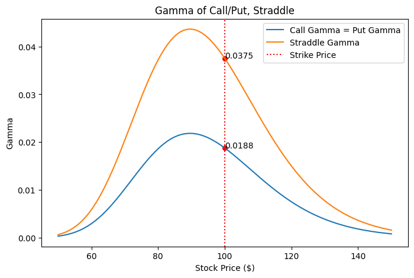

[output not shown]

```python
# --------------------------------------------
# 4.3.4.3 VISUALIZATION & INTERPRETATION
# ---------------------------------------------

# 1. GENERATE RANGE OF STOCK PRICES

S_values = np.linspace(50, 150, 200)

# 2. CALCULATE GAMMA FOR EACH STOCK PRICE

call_put_gamma = gamma_call_put(S_values, K, r, sigma, tau)
straddle_gamma = gamma_straddle(S_values, K, r, sigma, tau)

# 3. CREATE PLOT

# Set figure size
plt.figure(figsize=(8, 5))

# Plot gamma for call/put and straddle
plt.plot(S_values, call_put_gamma, label="Call Gamma = Put Gamma")
plt.plot(S_values, straddle_gamma, label="Straddle Gamma")

# Add label, title, legend
plt.xlabel("Stock Price ($)")
plt.ylabel("Gamma")
plt.title("Gamma of Call/Put, Straddle")

# Add vertical line at strike
plt.axvline(x=K,
            color="red",
            linestyle=":",
            label="Strike Price"
            )

# Add legend
plt.legend()

# Calculate gamma at strike
call_put_k_gamma = gamma_call_put(K, K, r, sigma, tau)
straddle_k_gamma = gamma_straddle(K, K, r, sigma, tau)

# Mark gamma at strike
plt.scatter(K, call_put_k_gamma, color="red", s=30)
plt.scatter(K, straddle_k_gamma, color="red", s=30)

# Annotate gamma at strike
plt.annotate(f"{call_put_k_gamma:.4f}", (K, call_put_k_gamma))
plt.annotate(f"{straddle_k_gamma:.4f}", (K, straddle_k_gamma))

# Show plot
plt.show()

# 4. INTERPRETATION

print("Gamma measures how much delta changes when the stock price changes.")
print("")

print(f"At the strike price K = {K}:")
print(f"Call/Put Gamma = {call_put_k_gamma:.4f}")
print(
    "If the stock price increases by $1, the delta of the call/put "
    f"option changes by approximately {call_put_k_gamma:.4f}."
)
print("")

print(f"Straddle Gamma = {straddle_k_gamma:.4f}")
print(
    "If the stock price increases by $1, the delta of the straddle "
    f"changes by approximately {straddle_k_gamma:.4f}."
)
print("")

print("THE RESULTS ARE CONSISTENT WITH THE EXPECTATIONS:")
print(
    "Small deviations occur due to specific parameters "
    "used in the Black-Scholes model."
)
print(
    "Gamma reaches its maximum around the strike price, where the option "
    "is at-the-money."
)
print(
    "This is because delta changes most rapidly when the option is close "
    "to the strike price."
)
print(
    "The gamma of the straddle has the highest value because it is the "
    "sum of the call gamma and the put gamma."
)
```

## 4.5 Examination of the option’s characteristics *regarding e.g. the option price, the risk profile, possibly exploring use or edge cases for the option and its plain vanilla components*

## 4.5.1 OPTION PRICE CHARACTERISTICS

- As described in the setup, the long straddle consists of two plain vanilla components:
  - one long call and
  - one long put
  - with the same strike price and maturity

Black-Scholes price of a Long Straddle:

$$ V_{\text{Straddle}}(S,K,r,\sigma,T) = C(S,K,r,\sigma,T) + P(S,K,r,\sigma,T) $$

```python
# ---------------------------------------------------------
# INTERACTIVE PLOT ON INFLUENCES ON OPTION PRICE
# ---------------------------------------------------------

# 1. DEFINE PARAMETERS
K = 100
r = 0.05
tau = 1.0
sigma = 0.2

# 2. RANGE OF VALUES FOR INTERACTIVE PLOT

# Range of underlying prices
S_values = np.linspace(50, 150, 300)


# 3. FUNCTION FOR INTERACTIVE PLOT

# Calculate option prices with BSM
def straddle_price_analysis(K, r, sigma, tau):

    # 3.1 CALCULATE BSM-PRICE FOR CALL, PUT, STRADDLE
    call_prices = bsOption(S_values, K, r, sigma, tau, "Call")
    put_prices = bsOption(S_values, K, r, sigma, tau, "Put")
    straddle_prices = call_prices + put_prices

    # 3.2 VISUALIZATION

    # Set figure size
    plt.figure(figsize=(9, 5))

    # Plot option prices for call, put, straddle
    plt.plot(S_values,
             call_prices,
             label="Call Price",
             linestyle="-",
             linewidth=2
             )
    plt.plot(S_values,
             put_prices,
             label="Put Price",
             linestyle="-",
             linewidth=2
             )
    plt.plot(S_values,
             straddle_prices,
             label="Straddle Price",
             linestyle="-",
             linewidth=2
             )

    # Vertical line at strike price
    plt.axvline(K,
                color="red",
                linestyle=":",
                label=f"Strike K = {K:.0f}"
                )

    # Labeling and title
    plt.xlabel("Stock Price($)")
    plt.ylabel("Option Price")
    plt.title(
        f"Option Price under Black-Scholes\n"
        f"σ={sigma:.2f}, T={tau:.2f}, r={r:.2%}, K={K:.1f}"
    )

    # Add legend
    plt.legend()

    # Show plot
    plt.show()


# 4. INTERACTION-SLIDER

# Slider for strike price
interact(
    straddle_price_analysis,
    K=FloatSlider(
        value=100,
        min=70,
        max=130,
        step=1,
        description="K"
    ),

    # Slider for risk-free rate
    r=FloatSlider(
        value=0.05,
        min=0.00,
        max=0.10,
        step=0.005,
        description="r"
    ),

    # Slider for volatility
    sigma=FloatSlider(
        value=0.20,
        min=0.05,
        max=0.80,
        step=0.01,
        description="σ"
    ),

    # Slider for time to maturity
    tau=FloatSlider(
        value=1.00,
        min=0.1,
        max=3.0,
        step=0.1,
        description="τ"
    )
)
```

```
interactive(children=(FloatSlider(value=100.0, description='K', max=130.0, min=70.0, step=1.0), FloatSlider(va…
```

```
<function __main__.straddle_price_analysis(K, r, sigma, tau)>
```

INTERPRETATION OF THE INTERACTIVE PLOT

1. VOLATILITY $\sigma$:
- Higher volatility increases the probability of large upward or downward movements
- Straddle benefits from strong movements
  - strong upward movement benefits Call
  - strong downward movement benefits Put

=> Option price increases with volatility

2. TIME TO MATURITY $\tau$:
- If time to maturity increases, the value of the long straddle increases
- A longer time horizont gives more opportunity for large price movement
- If time to maturity decreases, the option loses time value

=> Option price increases with $\tau$

3. RISK-FREE RATE r:
- If the risk-free rate increases, the call price increases and the put price decreases
- This leads to a mixed effect on the straddle
- The impact of the interest rate is less important than other parameters
4. STRIKE PRICE K:
- Shifts the center of the straddle
- If K increases, the put becomes more valuable and the call becomes less valuable
- If K decreases, the call becomes more valuable and the put becomes less valuable

## 4.5.2 PROFIT & RISK PROFILE

4.5.2.1 PROFIT/LOSS DIAGRAM

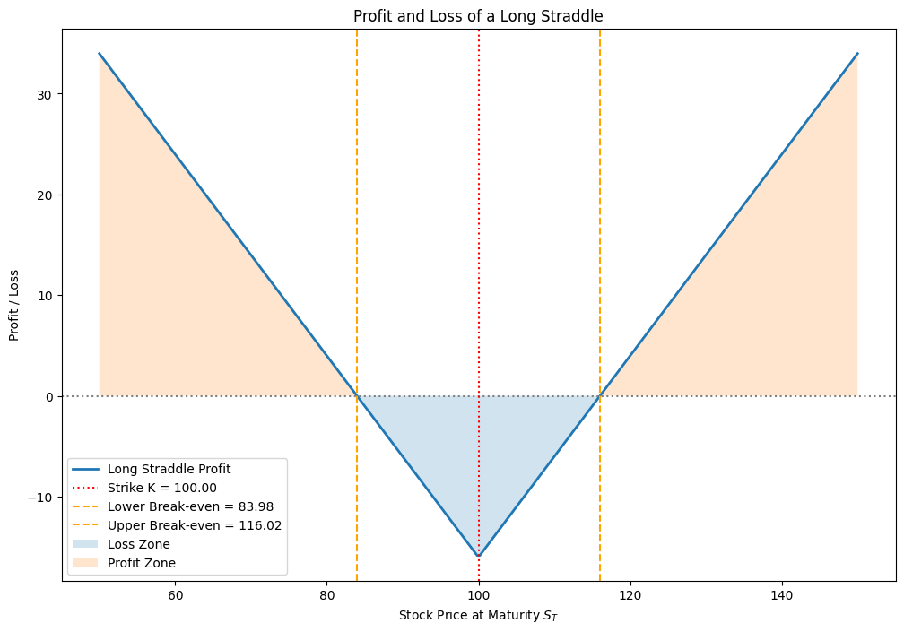

```
Current stock price S = 100.00
Stock price at maturity S_T = 120.00
Strike price K = 100.00

Realized profit of the long straddle: 3.9759
```

|  | Risk Measure | Value |
| --- | --- | --- |
| 0 | Call premium | 10.450584 |
| 1 | Put premium | 5.573526 |
| 2 | Total premium paid | 16.02411 |
| 3 | Realized straddle payoff | 20 |
| 4 | Realized profit | 3.97589 |
| 5 | Maximum loss | 16.02411 |
| 6 | Lower break-even | 83.97589 |
| 7 | Upper break-even | 116.02411 |
| 8 | Maximum downside profit | 83.97589 |
| 9 | Maximum upside profit | unlimited |

```python
# -------------------------------------------------------------------
# 4.5.2 PROFIT/LOSS OF A LONG STRADDLE
# -------------------------------------------------------------------

# DEFINE PARAMETERS

S = 100  # Current spot price
S_t = 120  # Realized stock price at maturity
K = 100
r = 0.05
sigma = 0.20
tau = 1.0


# 1. DEFINE PROFIT FUNCTION OF LONG STRADDLE

def straddle_profit_function(S, S_t, K, r, sigma, tau):

    # 1.1 CALCULATE PREMIUMS FOR CALL, PUT, STRADDLE

    call_premium = bsOption(S, K, r, sigma, tau, "Call")
    put_premium = bsOption(S, K, r, sigma, tau, "Put")
    total_premium = call_premium + put_premium

    # 1.2 GENERATE POSSIBLE STOCK PRICES AT MATURITY
    S_values = np.linspace(50, 150, 300)

    # 1.3 CALCULATE PROFIT FOR STRADDLE
    # Payoff for call, put, straddle at maturity
    call_payoff = np.maximum(S_values - K, 0)
    put_payoff = np.maximum(K - S_values, 0)
    straddle_payoff = call_payoff + put_payoff

    # Straddle profit = straddle payoff - total premium
    straddle_profit = straddle_payoff - total_premium

    # 1.4 CALCULATE REALIZED PROFIT
    # Realized payoff for stock price at maturity
    realized_call_payoff = max(S_t - K, 0)
    realized_put_payoff = max(K - S_t, 0)
    realized_straddle_payoff = realized_call_payoff + realized_put_payoff

    # realized profit = realized payoff - total premium
    realized_profit = realized_straddle_payoff - total_premium

    # 1.5 CALCULATE BREAK-EVEN
    # Calculate break-even points
    breakeven_low = K - total_premium
    breakeven_up = K + total_premium

    # 1.6 CALCULATE LIMITATIONS

    # Maximum total loss
    maximum_loss = total_premium

    # Maximum profit if stock price at maturity falls to 0
    maximum_downside_profit = K - total_premium

    # Maximum upside profit
    maximum_upside_profit = "unlimited"

    # 1.5 VISUALIZATION
    # Set figure size
    plt.figure(figsize=(12, 8))

    # Plot straddle profit
    plt.plot(
        S_values,
        straddle_profit,
        label="Long Straddle Profit",
        linewidth=2,
    )

    # Add horizontal line at profit = 0
    plt.axhline(0, color="grey", linestyle=":")

    # Add vertical lines for strike price and break-even points
    plt.axvline(K, color="red", linestyle=":", label=f"Strike K = {K:.2f}")
    plt.axvline(
        breakeven_low,
        color="orange",
        linestyle="--",
        label=f"Lower Break-even = {breakeven_low:.2f}",
    )
    plt.axvline(
        breakeven_up,
        color="orange",
        linestyle="--",
        label=f"Upper Break-even = {breakeven_up:.2f}",
    )

    # Fill areas for profit and loss zones
    plt.fill_between(
        S_values,  # X-values
        straddle_profit,  # Y-values
        0,  # Reference line for filling
        where=(straddle_profit < 0),  # Condition for loss zone
        alpha=0.2,  # Transparency for filling
        label="Loss Zone",
    )
    plt.fill_between(
        S_values,
        straddle_profit,
        0,
        where=(straddle_profit > 0),  # Condition for profit zone
        alpha=0.2,
        label="Profit Zone",
    )

    # Add title, labels, legend
    plt.title("Profit and Loss of a Long Straddle")
    plt.xlabel("Stock Price at Maturity $S_T$")
    plt.ylabel("Profit / Loss")
    plt.legend()

    # Show plot
    plt.show()

    # 1.5 INTERPRETATION
    # Print key paramters
    print(f"Current stock price S = {S:.2f}")
    print(f"Stock price at maturity S_T = {S_t:.2f}")
    print(f"Strike price K = {K:.2f}")
    print("")
    # Print realized profit
    print(f"Realized profit of the long straddle: {realized_profit:.4f}")

    # Generate summary table of results
    risk_summary = pd.DataFrame({
        "Risk Measure": [  # Column with measures
            "Call premium",
            "Put premium",
            "Total premium paid",
            "Realized straddle payoff",
            "Realized profit",
            "Maximum loss",
            "Lower break-even",
            "Upper break-even",
            "Maximum downside profit",
            "Maximum upside profit"
        ],
        "Value": [  # Column with measurments
            call_premium,
            put_premium,
            total_premium,
            realized_straddle_payoff,
            realized_profit,
            maximum_loss,
            breakeven_low,
            breakeven_up,
            maximum_downside_profit,
            maximum_upside_profit
        ],
    })

    # Displays table with results
    display(risk_summary)


# 2. APPLYS FUNCTION
straddle_profit_function(S, S_t, K, r, sigma, tau)
```

4.5.2.2 RISK PROFILE

- The maximum loss of a long straddle is limited to the total premium paid for the call and put option

- The strategy becomes profitable when the stock price at maturity moves significantly far away from the strike price

| maximum loss | maximum profit |
| --- | --- |
| total premium paid | theoretically unlimited |
| At $S_T$ ≈ K | For $\lvert S_T - K \rvert > C_0 + P_0$ and $S_T \to \infty$ |

## 4.5.3 USE CASES AND EDGE CASES

4.5.3.1 EDGE CASES

| Case | Interpretation |
| --- | --- |
| $S_T = K$ | Both options expire worthless; maximum loss equals $C_0 + P_0$ |
| $S_T < K - (C_0 + P_0)$ | The put payoff is large enough to generate a profit |
| $S_T > K + (C_0 + P_0)$ | The call payoff is large enough to generate a profit |
| $\text{Break-even}_{low} < S_T < \text{Break-even}_{up}$ | The strategy makes a loss because the price movement is not large enough to cover the premium |
| $S_T \to \infty$ | Upside profit is theoretically unlimited |
| $S_T = 0$ | Maximum downside profit is $K - (C_0 + P_0)$ |

4.5.3.2 USE CASES

- when a strong movement of the underlying is expected, but the direction is unclear
- for example:
  - Before earnings announcements
  - regulatory decisions
  - economic news